# Dominance Analysis

本稿では、順位に関する様々な指標をRを用いて算出するデモを行う。  
主に扱う内容は以下のとおりである。

- David’s Scoreの算出
- steepnessの算出
- linearity(h’)の算出

# 0. パッケージの読み込み

`steepness`パッケージ(Leiva and De Vries 2014)と`compete`パッケージ(Curley 2016)を用いる。  
それぞれの関数の使い方は以下のサイトを参照。  
[steepness](https://rdrr.io/cran/steepness/man/steepness-package.html)  
[compete](https://rdrr.io/cran/compete/)

```r
library(steepness)
library(compete)
library(tidyverse)
library(easystats)
```

# 1. David’s Scoreの算出

David’s Score(以下、DS)は、**個体間の相対的なdominanceの差の違い**を考慮して順位を算出してくれる指標である。  
一般的には個体の順位を高い方から順に1位, 2位, 3位, …と等間隔に割り振っていくため、1位 vs 2位と2位 vs 3位の間のdominanceの差が同じとみなされる。  
一方で、DSはその値の差が大きい個体間ほど、dominanceに差があることを表すことができる。  
例えば、A, B, Cという個体のDSがそれぞれ2, 4, 7とすると、AとBの間のdominanceの差はBとCの差よりも小さいことになる。  
なお、DSは値が高い個体ほど順位が高いことを表す。

それでは算出を行う。 算出には、個体間の勝敗を記録したマトリックスを用いる。  
本稿では、(Vervaecke et al. 2007)に載っている馬の攻撃交渉の勝敗データを用いる。  
データはdata frameではなく、matrixとして読み込む必要があるので、csvファイルなどから読み込むときは必要に応じて`as.matrix()`でmatrix化する必要がある。

**Rで直接マトリックスを作成する場合**

```r
mat <- matrix(c(0,58,50,61,32,37,29,39,25,8,0,22,22,9,27,20,10,48,
              3,3,0,19,29,12,13,19,8,5,8,9,0,33,38,35,32,57,
              4,7,9,1,0,28,26,16,23,4,3,0,0,6,0,7,6,12,
              2,0,4,1,4,4,0,5,3,0,2,1,1,5,8,3,0,10,3,1,3,0,0,4,1,2,0),
              nrow=9,byrow=TRUE)

individuals <- c("V","VS","B","FJ","PR","VB","TOR","MU","ZV") %>%
  as.character()

##列名と行名を追加
colnames(mat) <- individuals
rownames(mat) <- individuals

mat
```

```
##     V VS  B FJ PR VB TOR MU ZV
## V   0 58 50 61 32 37  29 39 25
## VS  8  0 22 22  9 27  20 10 48
## B   3  3  0 19 29 12  13 19  8
## FJ  5  8  9  0 33 38  35 32 57
## PR  4  7  9  1  0 28  26 16 23
## VB  4  3  0  0  6  0   7  6 12
## TOR 2  0  4  1  4  4   0  5  3
## MU  0  2  1  1  5  8   3  0 10
## ZV  3  1  3  0  0  4   1  2  0
```

**csvファイルから読みこむ場合**

```r
mat2 <- read_csv("matrix.csv") %>%
  ## 1列目を削除
  select(-1) %>%
  ## matrix形式に変換
  as.matrix()

## 行名を追加
rownames(mat2) <- colnames(mat2)
```

それでは、それぞれ算出する。  
微妙に値が異なることが分かる。

**Pijを用いた場合**

|  | NormDS |
| --- | --- |
| V | 7.366095 |
| VS | 6.009971 |
| B | 5.060312 |
| FJ | 5.576360 |
| PR | 4.266966 |
| VB | 2.188967 |
| TOR | 2.199558 |
| MU | 2.264827 |
| ZV | 1.066945 |

**Dijを用いた場合**

|  | NormDS |
| --- | --- |
| V | 7.286151 |
| VS | 5.917860 |
| B | 4.976697 |
| FJ | 5.534913 |
| PR | 4.247536 |
| VB | 2.250670 |
| TOR | 2.223747 |
| MU | 2.333602 |
| ZV | 1.228824 |

以下では、$D_ij$で算出した値を用いる。

# 2. steepnessの算出

続いて、順位序列のsteepnessを算出する。  
steepnessは**順位序列の厳しさ**を表し、例えば専制的な種ほどその値は高くなるとされる(Balasubramaniam et al. 2012)。  
X軸に順位が高い個体から名前を並べ、Y軸にnDSをプロットするとき、その回帰直線の傾きがsteepnessとなる。  
0から1の値を取り、1に近づくほどsteepnessが高いことを示す。

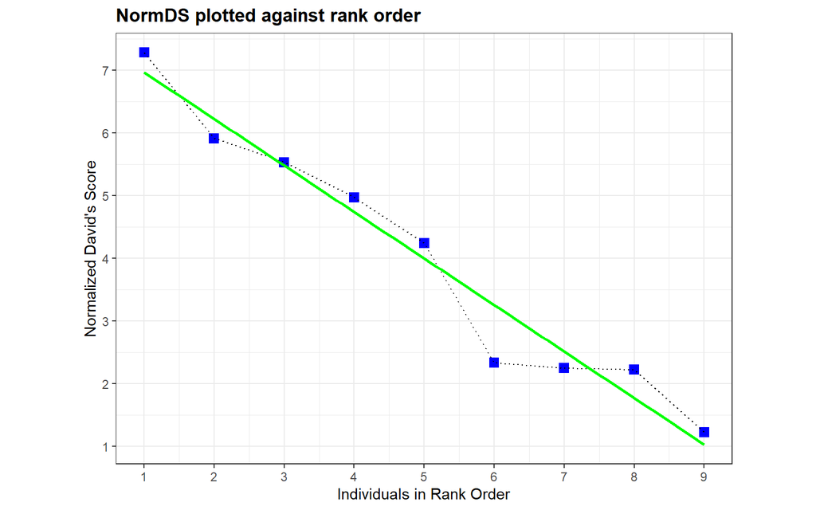

それでは、steepness(=傾き)はいくつになるだろうか。  
単回帰分析を行ってやると、その値は約0.7421となることがわかる。

```r
## NDSが高い順に並べ替え
nDS_d %>%
  data.frame() %>%
  arrange(-NormDS) %>%
  mutate(x = 1:n()) -> nDS_d2

## 単回帰分析
r <- lm(data=nDS_d2, NormDS~x)

## 単回帰分析の結果
r$coefficients[[2]]
```

```
## [1] -0.7420538
```

`steepness`パッケージでは、わざわざ単回帰を行わなくてもsteepnessを算出することができる。

```r
stp <- steepness::steeptest(mat, names = individuals,
                 rep = 1000, method = "Dij",
                 order = TRUE)

stp$Stp
```

```
## [1] 0.7420538
```

個体の勝敗がランダムに決まるときに比べて、steepnessが有意に高いかを検定することもできる。  
結果、steepnessはランダムな場合よりも有意に高いことが分かる。

```r
summary(stp)
```

```
##
## RESULTS OF STEEPNESS ANALYSIS OF THE MATRIX OF DYADIC DOMINANCES CORRECTED FOR CHANCE
## =====================================================================================
##
##
## Dij
## ===
##
##           V      VS      FJ        B      PR     MU     VB    TOR     ZV
## V   0.00000 0.87313 0.93519 0.917910 0.87838 0.8929 0.9219 0.9875 0.8793
## VS  0.12687 0.00000 0.86538 0.725806 0.55882 0.8871 0.9762 0.8077 0.9700
## FJ  0.06481 0.13462 0.00000 0.672414 0.75641 0.9615 0.7500 0.9286 0.7083
## B   0.08209 0.27419 0.32759 0.000000 0.95714 0.9872 0.9595 0.9559 0.9914
## PR  0.12162 0.44118 0.24359 0.042857 0.00000 0.8143 0.8548 0.7500 0.9792
## MU  0.10714 0.11290 0.03846 0.012821 0.18571 0.0000 0.6250 0.4333 0.7353
## VB  0.07812 0.02381 0.25000 0.040541 0.14516 0.3750 0.0000 0.6111 0.7000
## TOR 0.01250 0.19231 0.07143 0.044118 0.25000 0.5667 0.3889 0.0000 0.8077
## ZV  0.12069 0.03000 0.29167 0.008621 0.02083 0.2647 0.3000 0.1923 0.0000
##
##
## DAVID'S SCORES
## ==============
##
##     DS Values
## V      29.575
## VS     17.261
## FJ     13.814
## B       8.790
## PR      2.228
## MU    -14.998
## VB    -15.744
## TOR   -15.986
## ZV    -24.941
##
##
## NORMALIZED DAVID'S SCORES
## =========================
##
##     NormDS Values
## V           7.286
```

[output cut: 22 more lines]

```
##
## SUMMARY STATISTICS OF THE RANDOMIZATION PROCEDURE FOR TESTING STEEPNESS BASED ON THE Dij MEASURES
## =================================================================================================
##                      Stp
## Empirical value    0.742
## Right p-value      0.001
## Left p-value       1.000
## N simulations   1000.000
## Mean               0.297
## Variance           0.005
## Minimum            0.110
## 25th Pctl          0.247
## 50th Pctl          0.294
## 75th Pctl          0.348
## Maximum            0.526
```

# 3. linearityの算出

Linearityは**順位序列がどの程度直線的か**を示す指標である。  
直線的とは、順位序列に逆転や三すくみのような関係がないことを指す。  
linearityの指標としては$h'$がよく用いられる(De Vries 1995)。

`compete`パッケージを用いて以下のように算出することができる。

```r
lin <- devries(mat, Nperms = 10000)

lin$`h-modified`
```

```
## [1] 0.9667
```

$h'$は0.9667なので、順位序列の直線性はかなり高いことが分かる。  
個体の勝敗がランダムに割り振られたときと比較して$h'$が有意に高いかも検定することができる。  
今回は、有意に高いことが示された。

```r
lin$`p-value`
```

```
## [1] 0
```

# 4. Elorating packageを用いた方法

なお、以上で算出した指標は`EloRating`パッケージ(Neumann 2011)でも求めることができる。個人的にはデータフレームとして出力してくれるので、こちらの方が使いやすい。  
[詳細はこちら](https://rdrr.io/cran/EloRating/)

```r
library(EloRating)
```

## 4.1 David’s Scoreとsteepness

算出する際、行列の名前が入っていなければいけないよう。

**Davis’s Score**  
`prop=`で”Dij”か”Pij”を指定。

```r
EloRating::DS(mat, prop = "Dij")
```

| ID | DS | normDS |
| --- | --- | --- |
| V | 29.575 | 7.286 |
| VS | 17.261 | 5.918 |
| FJ | 13.814 | 5.535 |
| B | 8.790 | 4.977 |
| PR | 2.228 | 4.248 |
| MU | -14.998 | 2.334 |
| VB | -15.744 | 2.251 |
| TOR | -15.986 | 2.224 |
| ZV | -24.941 | 1.229 |

**steepness**

```r
EloRating::steepness(mat, nrand = 10000)
```

```
##      steep   expected          p      nrand
##     0.7421     0.3024     0.0001 10000.0000
```

同様の結果を得られた。

## 4.2 linearity

$h'$は以下のように求められる。  
同様の結果が得られた。

```r
EloRating::h.index(mat, loop = 1000)
```

| variable | value |
| --- | --- |
| N | 9.0000 |
| h index | 0.9667 |
| h' index | 0.9667 |
| expected h | 0.2985 |
| p right | 0.0010 |
| randomizations | 1000.0000 |
| tied | 0.0000 |
| unknown | 0.0000 |

$h'$に変わる指標として、**transitivity**という指標も提案されている(Shizuka and McDonald 2012)。

```r
EloRating::transitivity(mat, runs = 1000)
```

```
##       Pt     ttri        p     runs
##    0.988    0.952    0.000 1000.000
```

## 4.3 おまけ(Elo-ratingの計算)

`EloRating`パッケージでは、他にも順位序列に関する様々な指標が求められるよう（例えば、時間的な順位の変化を考慮する**Elo-rating**など。詳細は[こちら](https://rdrr.io/cran/EloRating/f/inst/doc/EloRating_tutorial.pdf)）。

例えば、Elo-ratingは以下のような日付と勝敗が示されたデータをもちいて算出できる。

```r
data(adv)

head(adv)
```

|  | Date | Time | winner | loser |
| --- | --- | --- | --- | --- |
| 1 | 2010-01-01 | 15:38:13 | b | c |
| 2 | 2010-01-02 | 16:07:30 | c | g |
| 3 | 2010-01-03 | 10:26:45 | c | d |
| 4 | 2010-01-04 | 15:44:58 | c | d |
| 5 | 2010-01-05 | 14:26:55 | b | e |
| 6 | 2010-01-06 | 17:31:02 | d | f |

Elo-ratingの計算。

```r
res <- elo.seq(winner = adv$winner, loser = adv$loser, Date = adv$Date)
summary(res)
```

```
## Elo ratings from 7 individuals
## total (mean/median) number of interactions: 33 (9.4/9)
## range of interactions: 7 - 11
## date range: 2010-01-01 - 2010-02-02
## startvalue: 1000
## uppon arrival treatment: average
## k: 100
## proportion of draws in the data set: 0
```

ある日付におけるElo-ratingは以下のように求められる。

```r
extract_elo(res, extractdate = "2010-01-28") %>%
  data.frame() %>%
  rename("Elo-rating" = ".") %>%
  rownames_to_column(var = "ID")
```

| ID | Elo-rating |
| --- | --- |
| c | 1207 |
| b | 1137 |
| d | 1095 |
| f | 1004 |
| e | 936 |
| g | 878 |
| a | 743 |

日付を指定しなければ最終日のElo-ratingが求められる。

```r
extract_elo(res) %>%
  data.frame() %>%
  rename("Elo-rating" = ".") %>%
  rownames_to_column(var = "ID")
```

| ID | Elo-rating |
| --- | --- |
| b | 1203 |
| c | 1148 |
| d | 1116 |
| f | 1004 |
| e | 982 |
| g | 843 |
| a | 704 |

Elo-ratingの時系列的変化は以下のように描画できる。

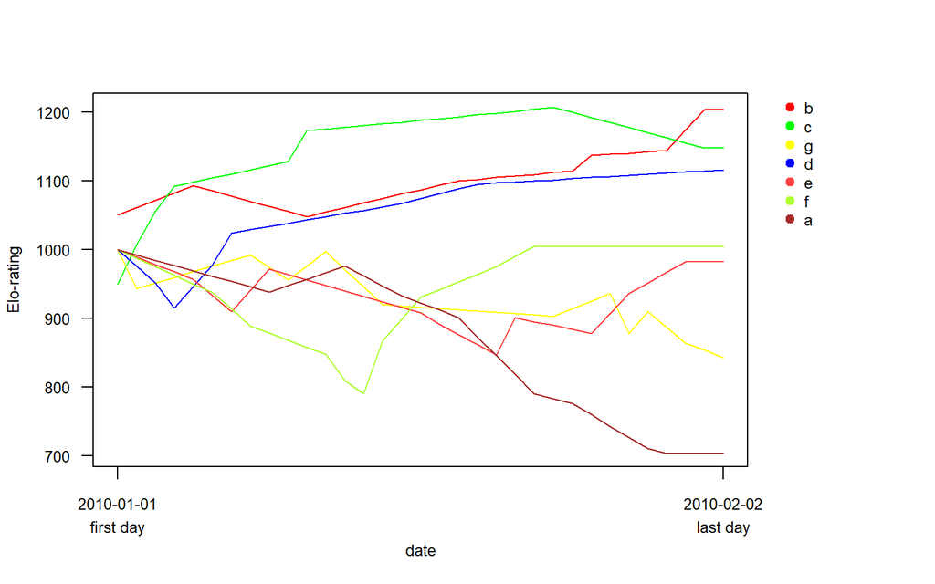

```r
eloplot(res)
```

## 4.4 おまけ(その他)

`EloRaing`パッケージでは、様々な論文で用いられている勝敗マトリクスのデータも豊富に取り込める。

de Vries et al. (2006)のボノボのデータ。

```r
data(bonobos)
bonobos
```

```
##    He Dz Ho De Ko Re Ki
## He  0  0  1  2 10 63  8
## Dz  0  0  2  3  0 88  4
## Ho  0  0  0  4 65 84  3
## De  0  0  0  0  0 80 10
## Ko  0  0  0  0  0  4  1
## Re  0  1  5  0 10  0  6
## Ki  0  0  0  0  0  2  0
```

nDSとsteepnessの算出。

```r
DS(bonobos,prop = "Dij")
```

| ID | DS | normDS |
| --- | --- | --- |
| He | 10.9875 | 4.570 |
| Dz | 9.6891 | 4.384 |
| Ho | 7.3927 | 4.056 |
| De | 0.8606 | 3.123 |
| Ko | -7.2559 | 1.963 |
| Re | -8.8494 | 1.736 |
| Ki | -12.8245 | 1.168 |

```r
steepness(bonobos,Dij=TRUE, nrand = 10000)
```

```
##      steep   expected          p      nrand
##     0.6284     0.2668     0.0001 10000.0000
```

de Vries (1998)のデータ。

```r
data(devries98)
devries98
```

```
##   a v b h g w e k c y
## a 0 5 4 6 3 0 2 2 3 1
## v 0 0 0 0 2 1 2 0 7 7
## b 0 0 0 0 1 1 1 2 2 2
## h 0 3 0 0 0 0 6 0 2 5
## g 0 0 0 1 0 2 4 0 3 0
## w 2 0 0 3 0 0 0 0 2 1
## e 0 0 0 0 0 0 0 0 0 4
## k 0 0 0 0 0 0 0 0 2 1
## c 0 0 0 0 0 1 0 2 0 6
## y 0 0 0 0 0 0 0 0 2 0
```

$h'$とtransitivityの算出。

```r
h.index(devries98, loop = 10000)
```

| variable | value |
| --- | --- |
| N | 10.0000 |
| h index | 0.5818 |
| h' index | 0.6424 |
| expected h | 0.2734 |
| p right | 0.0092 |
| randomizations | 10000.0000 |
| tied | 1.0000 |
| unknown | 10.0000 |

```r
transitivity(devries98, runs = 10000)
```

```
##        Pt      ttri         p      runs
##     0.907     0.630     0.010 10000.000
```

# References

Balasubramaniam KN, Dittmar K, Berman CM, et al (2012) Hierarchical steepness and phylogenetic models: Phylogenetic signals in macaca. Anim Behav 83:1207–1218

Curley J (2016) [Compete: Analyzing competitive interaction data: R package version 0.1](https://rdrr.io/cran/compete/)

De Vries H (1995) An improved test of linearity in dominance hierarchies containing unknown or tied relationships. Anim Behav 50:1375–1389

De Vries H, Stevens JMG, Vervaecke H (2006) Measuring and testing the steepness of dominance hierarchies. Anim Behav 71:585–592

Leiva H, De Vries H (2014) [Testing steepness of dominance hierarchie](https://rdrr.io/cran/steepness/man/steepness-package.html)

Neumann C (2011) [EloRating: Animal dominance hierarchies by elo rating](https://rdrr.io/cran/EloRating/)

Shizuka D, McDonald DB (2012) A social network perspective on measurements of dominance hierarchies. Anim Behav 83:925–934

Vervaecke H, Stevens JMG, Vandemoortele H, et al (2007) Aggression and dominance in matched groups of subadult icelandic horses (equus caballus). J Ethol 25:239–248